# Assignment 4

Tasleem Moossun

2023-04-05

### Assignment 4

Loading the libraries

```r
#Loading up libraries
library(randomForest)
```

```r
library(rpart)
library(ROCR)
library(ggplot2)
```

# Part 1: Data Pre-processing

Data pre-processing steps:

1. Reading the winequality csv file for both the red and white csv files and adding the semi-colon delimiter. Then assigning the data to a dataframe.
2. Checking for NAs in each dataframe
3. Removing any duplicate rows in both dataframes

```r
#Downloading data and preprocessing
df <- read.csv("C:/Users/tasle/Downloads/winequality-red.csv",sep = ";")
df1 <- read.csv("C:/Users/tasle/Downloads/winequality-white.csv",sep = ";")
str(df)
```

```
## 'data.frame':    1599 obs. of  12 variables:
##  $ fixed.acidity       : num  7.4 7.8 7.8 11.2 7.4 7.4 7.9 7.3 7.8 7.5 ...
##  $ volatile.acidity    : num  0.7 0.88 0.76 0.28 0.7 0.66 0.6 0.65 0.58 0.5 ...
##  $ citric.acid         : num  0 0 0.04 0.56 0 0 0.06 0 0.02 0.36 ...
##  $ residual.sugar      : num  1.9 2.6 2.3 1.9 1.9 1.8 1.6 1.2 2 6.1 ...
##  $ chlorides           : num  0.076 0.098 0.092 0.075 0.076 0.075 0.069 0.065 0.073 0.071 ...
##  $ free.sulfur.dioxide : num  11 25 15 17 11 13 15 15 9 17 ...
##  $ total.sulfur.dioxide: num  34 67 54 60 34 40 59 21 18 102 ...
##  $ density             : num  0.998 0.997 0.997 0.998 0.998 ...
##  $ pH                  : num  3.51 3.2 3.26 3.16 3.51 3.51 3.3 3.39 3.36 3.35 ...
##  $ sulphates           : num  0.56 0.68 0.65 0.58 0.56 0.56 0.46 0.47 0.57 0.8 ...
##  $ alcohol             : num  9.4 9.8 9.8 9.8 9.4 9.4 9.4 10 9.5 10.5 ...
##  $ quality             : int  5 5 5 6 5 5 5 7 7 5 ...
```

```r
#No NAs
which(is.na(df))
```

```
## integer(0)
```

```r
which(is.na(df1))
```

```
## integer(0)
```

```r
#no categorical variable or factor variable

#removing any duplicate rows in df and df1
df <- df[!duplicated(df),]
df1 <- df1[!duplicated(df1),]
```

# Part 2: Prediction White Wine Quality

Part 2A: Regression: Evaluating the performance of a single tree, bagging, random forest and linear model using RMSPE. Lower RMSPE indicates that the model is making more accurate predictions

```r
#Regression
n <- 25 # data points
B <- 100 # number of trees
#creating containers to store the RMSPE for each model
RMSPE1 <- c()
RMSPE2 <- c()
RMSPE3 <- c()
RMSPE4 <- c()
for (i in 1:n) {
  ind <- sample(nrow(df1), nrow(df1), replace = TRUE)

  train <- df1[ind, ]
  test <- df1[-ind, ]

  p = ncol(train)-1

  model1 <- rpart(quality~., data =train) # Single Tree
  model2 <- randomForest(quality~., ntree = B, mtry = p, data = train) #Bagged
  model3 <- randomForest(quality~., ntree = B, data = train) # RF
  model4 <- lm(quality ~., data=train)

  yhat1 <- predict(model1, test)

  yhat2 <- predict(model2, test)

  yhat3 <- predict(model3, test)

  yhat4 <- predict(model4, test)

  RMSPE1[i] <- sqrt(mean((test$quality - yhat1)^2))
  RMSPE2[i] <- sqrt(mean((test$quality - yhat2)^2))
  RMSPE3[i] <- sqrt(mean((test$quality - yhat3)^2))
  RMSPE4[i] <- sqrt(mean((test$quality - yhat4)^2))
}

#Calculating the mean and standard deviation of each RMSPE for each model
mean(RMSPE1)
```

```
## [1] 0.7738499
```

```r
mean(RMSPE2)
```

```
## [1] 0.7175277
```

```r
mean(RMSPE3)
```

```
## [1] 0.7062498
```

```r
mean(RMSPE4)
```

```
## [1] 0.7530501
```

```r
sd(RMSPE1)
```

```
## [1] 0.01273413
```

```r
sd(RMSPE2)
```

```
## [1] 0.01629862
```

```r
sd(RMSPE3)
```

```
## [1] 0.01456505
```

```r
sd(RMSPE4)
```

```
## [1] 0.01502802
```

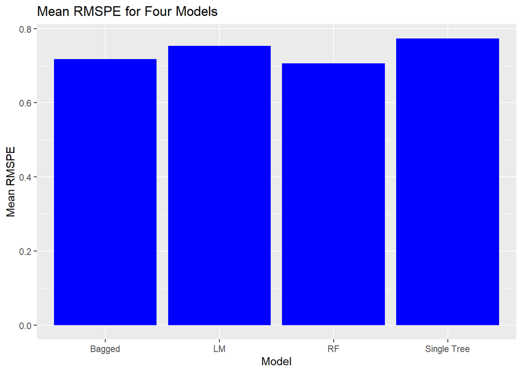

```r
# create a data frame with the mean RMSPE values for each model
model_rmspe <- data.frame(model = c("Single Tree", "Bagged", "RF", "LM"),
                          mean_rmspe = c(mean(RMSPE1), mean(RMSPE2), mean(RMSPE3), mean(RMSPE4)))

# create a bar plot of the mean RMSPE values
library(ggplot2)
ggplot(model_rmspe, aes(x = model, y = mean_rmspe)) +
  geom_bar(stat = "identity", fill = "blue") +
  labs(title = "Mean RMSPE for Four Models",
       x = "Model",
       y = "Mean RMSPE")
```

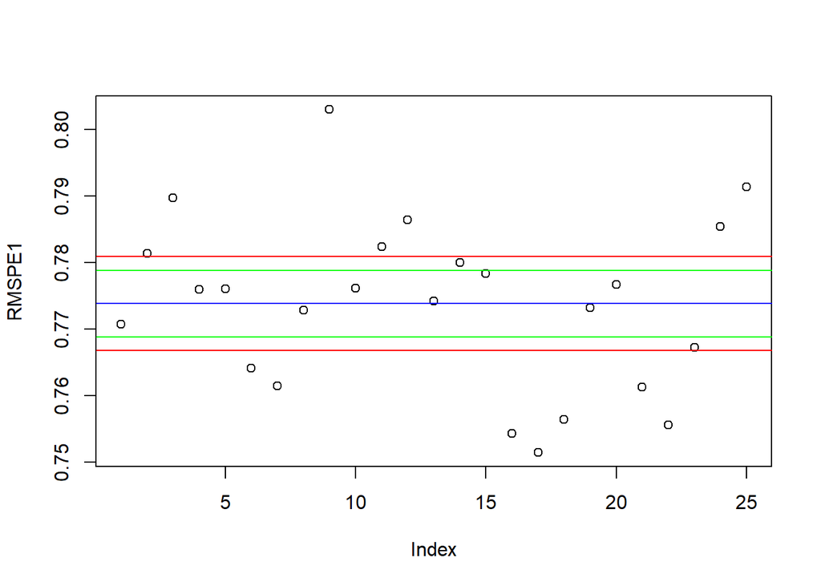

```r
mean_rmspe1 <- mean(RMSPE1)  # mean RMSPE
sd_rmspe1 <- sd(RMSPE1)  # standard deviation of RMSPE
n <- length(RMSPE1)  # sample size
se_rmspe1 <- sd_rmspe1 / sqrt(n)  # standard error of the mean
ci95rmspe1 <- 1.96 * se_rmspe1 # 95% confidence interval
ci5rmspe1 <- 2.776 * se_rmspe1

mean_rmspe2 <- mean(RMSPE2)  # mean RMSPE
sd_rmspe2 <- sd(RMSPE2)  # standard deviation of RMSPE
n <- length(RMSPE2)  # sample size
se_rmspe2 <- sd_rmspe2 / sqrt(n)  # standard error of the mean
ci95rmspe2 <- 1.96 * se_rmspe2 # 95% confidence interval
ci5rmspe2 <- 2.776 * se_rmspe2

mean_rmspe3 <- mean(RMSPE3)  # mean RMSPE
sd_rmspe3 <- sd(RMSPE3)  # standard deviation of RMSPE
n <- length(RMSPE3)  # sample size
se_rmspe3 <- sd_rmspe3 / sqrt(n)  # standard error of the mean
ci95rmspe3 <- 1.96 * se_rmspe3 # 95% confidence interval
ci5rmspe3 <- 2.776 * se_rmspe3

mean_rmspe4 <- mean(RMSPE4)  # mean RMSPE
sd_rmspe4 <- sd(RMSPE4)  # standard deviation of RMSPE
n <- length(RMSPE4)  # sample size
se_rmspe4 <- sd_rmspe4 / sqrt(n)  # standard error of the mean
ci95rmspe4 <- 1.96 * se_rmspe4 # 95% confidence interval
ci5rmspe4 <- 2.776 * se_rmspe4 # 5% confidence interval

# create the plot of RMSPE values\
# add a line representing the mean RMSPE
lower_ci95 <- mean_rmspe1 - ci95rmspe1
upper_ci95 <- mean_rmspe1 + ci95rmspe1
lower_ci5 <- mean_rmspe1 - ci5rmspe1
upper_ci5 <- mean_rmspe1 + ci5rmspe1
plot(RMSPE1)
abline(h = mean_rmspe1, col = "blue")
abline(h = lower_ci95, col = "green")
abline(h = upper_ci95, col = "green")
abline(h = lower_ci5, col = "red")
abline(h = upper_ci5, col = "red")
```

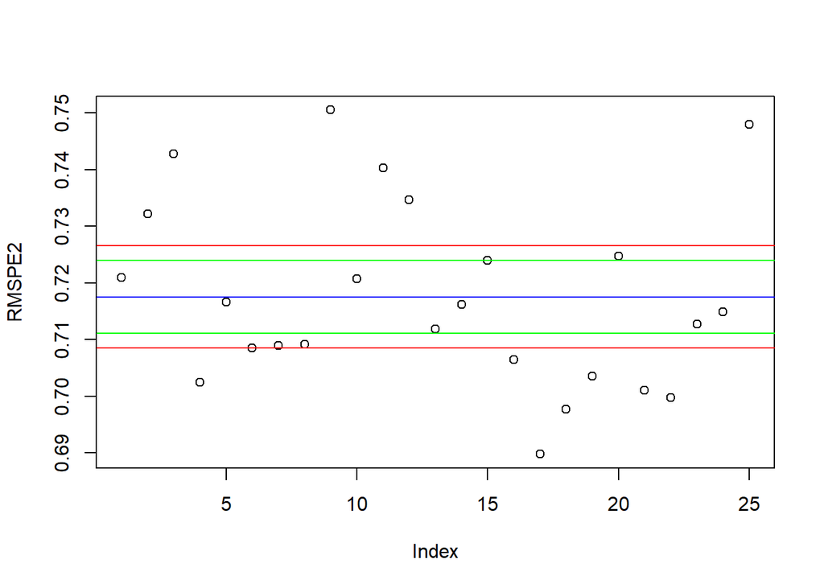

```r
lower_ci95rmspe2 <- mean_rmspe2 - ci95rmspe2
upper_ci95rmspe2 <- mean_rmspe2 + ci95rmspe2
lower_ci5rmspe2 <- mean_rmspe2 - ci5rmspe2
upper_ci5rmspe2 <- mean_rmspe2 + ci5rmspe2
plot(RMSPE2)
abline(h = mean_rmspe2, col = "blue")
abline(h = lower_ci95rmspe2, col = "green")
abline(h = upper_ci95rmspe2, col = "green")
abline(h = lower_ci5rmspe2, col = "red")
abline(h = upper_ci5rmspe2, col = "red")
```

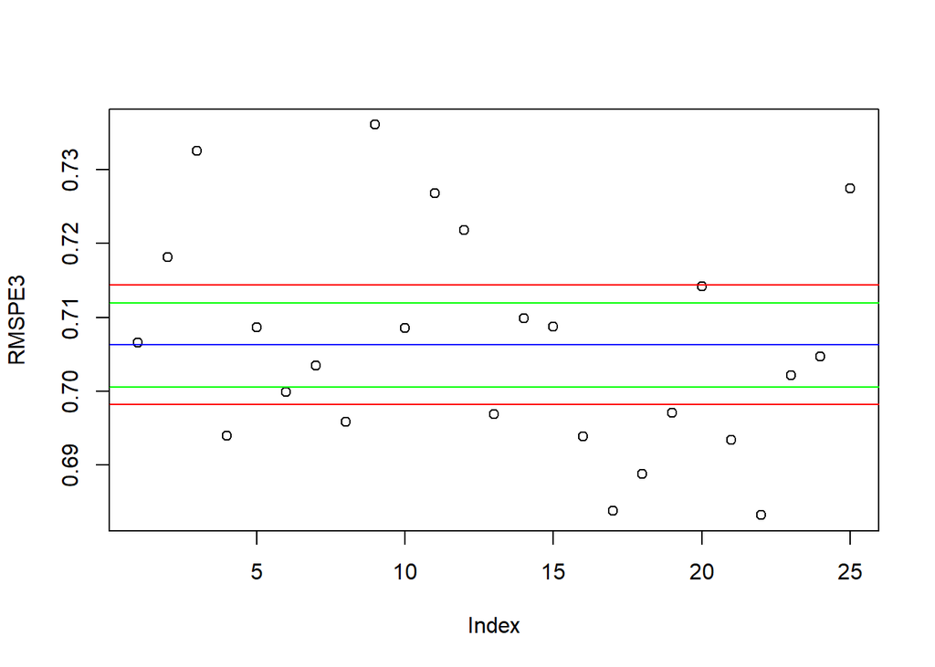

```r
lower_ci95rmspe3 <- mean_rmspe3 - ci95rmspe3
upper_ci95rmspe3 <- mean_rmspe3 + ci95rmspe3
lower_ci5rmspe3 <- mean_rmspe3 - ci5rmspe3
upper_ci5rmspe3 <- mean_rmspe3 + ci5rmspe3
plot(RMSPE3)
abline(h = mean_rmspe3, col = "blue")
abline(h = lower_ci95rmspe3, col = "green")
abline(h = upper_ci95rmspe3, col = "green")
abline(h = lower_ci5rmspe3, col = "red")
abline(h = upper_ci5rmspe3, col = "red")
```

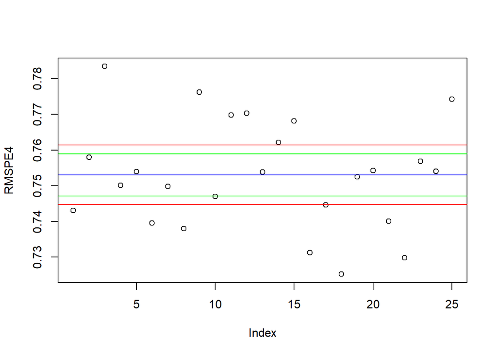

```r
lower_ci95rmspe4 <- mean_rmspe4 - ci95rmspe4
upper_ci95rmspe4 <- mean_rmspe4 + ci95rmspe4
lower_ci5rmspe4 <- mean_rmspe4 - ci5rmspe4
upper_ci5rmspe4 <- mean_rmspe4 + ci5rmspe4
plot(RMSPE4)
abline(h = mean_rmspe4, col = "blue")
abline(h = lower_ci95rmspe4, col = "green")
abline(h = upper_ci95rmspe4, col = "green")
abline(h = lower_ci5rmspe4, col = "red")
abline(h = upper_ci5rmspe4, col = "red")
```

Part 2B: Classification

Loading the randomForestExplainer library to be able to use the varImpPlot(model) function to create a plot of the variable importance measures for each predictor variable in a random forest model

```r
library(randomForestExplainer)
```

Pre-processing the data: 1) Reading the csv file for white wine (Already completed in above code chunk) 2) Creating character vector a that contains the name of the columns that will be using from df 3) Removing any NAs as randomForest can’t handle NAs 4) turning quality into a binary variable where if quality score is greater or equal to 6 then use label better-than-average and if less then use less-than-average 5) Convert the quality_binary to factor variable to be able to perform prediction

```r
# Data for rpart
#remove(list = ls())
df <- read.csv("C:/Users/tasle/Downloads/winequality-white.csv", sep = ";")
a <- c("quality", "fixed.acidity","volatile.acidity", "citric.acid", "residual.sugar", "chlorides", "free.sulfur.dioxide", "total.sulfur.dioxide", "density", "pH", "sulphates", "alcohol")
dd <- df[, a]
df <- dd # for rpartdf
dff <- df[complete.cases(df), ] # for rf
dff$quality_binary <- ifelse(dff$quality >= 6, "better-than-average", "less-than-average")
dff$quality_binary <- as.factor(dff$quality_binary) # Convert to factor
```

Splitting the data into training and test data Creating the AUC container Creating the vector for the maximum number of terminal nodes for Random Forest Fitting the classification model using Random Forest Predicting using test data Calculating AUC at each terminal nodes

```r
ind2 <- sample(nrow(dff), nrow(dff)*0.8, replace = TRUE)
train <- dff[ind2, ]
test <- dff[-ind2, ]
AUC <- c()
maxnode <- c(10, 50, 100, 250, 500, 750, 1000,1250)
for (i in 1:length(maxnode)) {
  model_rf <- randomForest(quality_binary ~ fixed.acidity + citric.acid + residual.sugar + chlorides + total.sulfur.dioxide + density + pH + sulphates + alcohol,
                           maxnodes = maxnode[i], data = train,
                           localImp = TRUE)
  phat <- predict(model_rf, test, type = "prob")[, 2]

  # AUC
  pred_rocr1 <- prediction(phat, test$quality_binary)
  auc_ROCR1 <- performance(pred_rocr1, measure = "auc")
  AUC[i] <- auc_ROCR1@y.values[[1]]
  print(c(maxnode[i], AUC[i]))

}
```

```
## [1] 10.0000000  0.7815398
## [1] 50.0000000  0.8137685
## [1] 100.0000000   0.8337141
## [1] 250.0000000   0.8602302
## [1] 500.0000000   0.8781154
## [1] 750.0000000   0.8758794
## [1] 1000.0000000    0.8777752
## [1] 1250.0000000    0.8773879
```

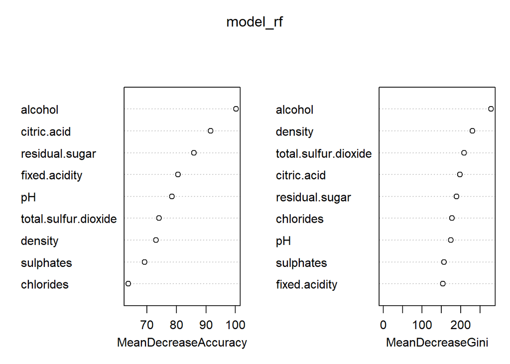

```r
varImpPlot(model_rf)
```

```r
min_depth_frame <- min_depth_distribution(model_rf)
importance_frame <- measure_importance(model_rf)
importance_frame
```

```
##               variable mean_min_depth no_of_nodes accuracy_decrease
## 1              alcohol          1.106       21830        0.16886407
## 2            chlorides          2.182       25019        0.07933713
## 3          citric.acid          1.980       25104        0.08908678
## 4              density          1.808       27430        0.12640754
## 5        fixed.acidity          2.672       23957        0.06168063
## 6                   pH          2.678       26371        0.07214135
## 7       residual.sugar          2.600       27236        0.08486727
## 8            sulphates          3.096       24912        0.06425187
## 9 total.sulfur.dioxide          1.958       28987        0.08607735
##   gini_decrease no_of_trees times_a_root       p_value
## 1      277.9805         500          166  1.000000e+00
## 2      177.0227         500           87  9.999863e-01
## 3      198.1493         500           37  9.998565e-01
## 4      230.4738         500          113  8.746641e-32
## 5      154.1461         500            1  1.000000e+00
## 6      173.9959         500           13  9.866926e-07
## 7      188.8244         500            6  1.094366e-25
## 8      156.3364         500            2  9.999995e-01
## 9      208.6785         500           75 9.527470e-105
```

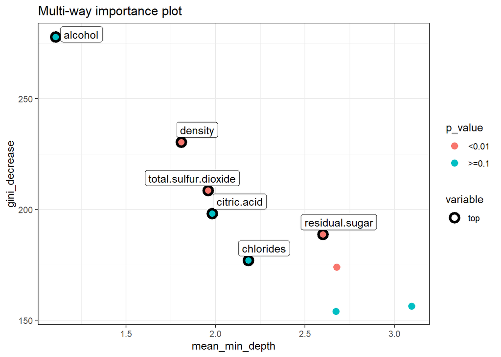

```r
plot_multi_way_importance(importance_frame, x_measure = "mean_min_depth",
                          y_measure = "gini_decrease",
                          size_measure = "p_value", no_of_labels = 6)
```

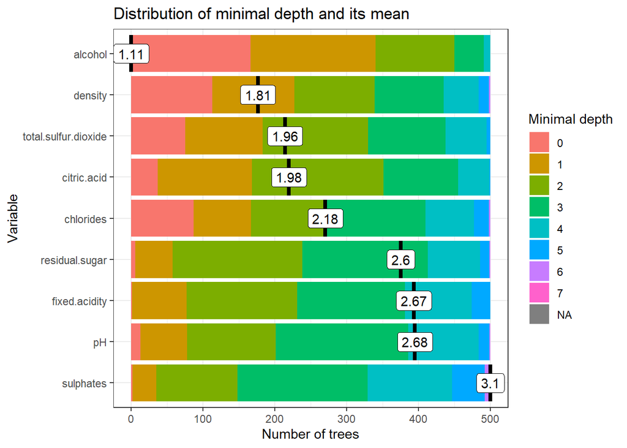

```r
plot_min_depth_distribution(min_depth_frame, mean_sample = "all_trees", k =20,
                            main = "Distribution of minimal depth and its mean")
```

Part 3: Predicting the wine type, red or white

Loading the libraries

```r
library(dplyr) # Loaded in order to use the function mutate to add the wine_type column to the df
library(caret)
```

Data pre-processing : Reading the csv files Merging the red and white csv and adding a new column called wine_type Where wine_type will be a factor variable

```r
# Read data
red_wine <- read.csv("C:/Users/tasle/Downloads/winequality-red.csv", sep = ";")
white_wine <- read.csv("C:/Users/tasle/Downloads/winequality-white.csv", sep = ";")

# Add wine_type column
red_wine <- red_wine %>%
  mutate(wine_type = "red")
white_wine <- white_wine %>%
  mutate(wine_type = "white")

# Combine datasets
df2 <- rbind(red_wine, white_wine)

# Clean dataset
dff <- df2[complete.cases(df2), ]

# Create binary wine_type variable
dff$wine_type <- as.factor(ifelse(dff$wine_type == "red", 1, 0))
```

```r
# Split the dataset into training and testing sets
#set.seed(123)
ind2 <- sample(nrow(df2), nrow(df2)*0.8, replace = TRUE)
train <- dff[ind2, ]
test <- dff[-ind2, ]

# Random Forest model
AUC <- c()
maxnode <- c(10, 50, 100, 250, 500, 750, 1000,1250,1500,1750)
for (i in 1:length(maxnode)) {
  model_rf <- randomForest(wine_type ~ quality + fixed.acidity + citric.acid + residual.sugar + chlorides + total.sulfur.dioxide + density + pH + sulphates + alcohol,
                           maxnodes = maxnode[i], data = train,
                           localImp = TRUE)
  phat <- predict(model_rf, test, type = "prob")[, 2]

  # AUC
  pred_rocr1 <- prediction(phat, test$wine_type)
  auc_ROCR1 <- performance(pred_rocr1, measure = "auc")
  AUC[i] <- auc_ROCR1@y.values[[1]]
  print(c(maxnode[i], AUC[i]))

}
```

```
## [1] 10.0000000  0.9949561
## [1] 50.0000000  0.9976357
## [1] 100.0000000   0.9975964
## [1] 250.0000000   0.9975473
## [1] 500.0000000   0.9987681
## [1] 750.0000000   0.9987563
## [1] 1000.0000000    0.9976018
## [1] 1250.000000    0.998784
## [1] 1500.0000000    0.9988915
## [1] 1750.0000000    0.9989783
```

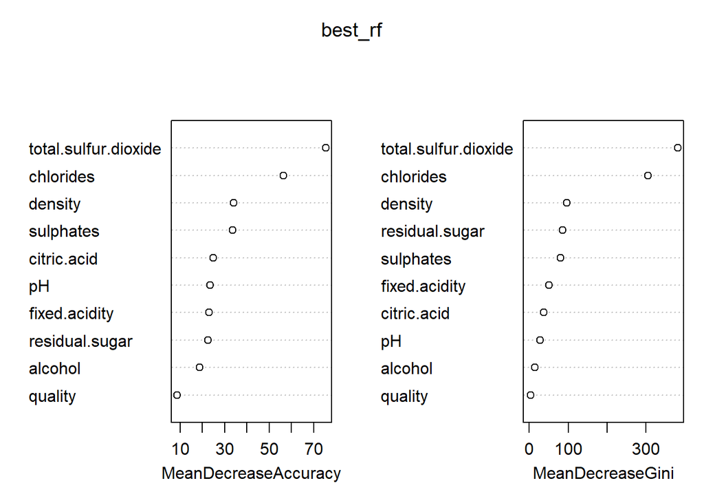

```r
# Identify the best Random Forest model and calculate its AUC on test data
best_rf_index <- which.max(AUC)
best_rf <- randomForest(wine_type ~ quality + fixed.acidity + citric.acid + residual.sugar + chlorides + total.sulfur.dioxide + density + pH + sulphates + alcohol,
                        maxnodes = maxnode[best_rf_index], data = test,
                        localImp = TRUE)

# Variable importance for the best Random Forest model
varImpPlot(best_rf)
```

```r
# Logistic Regression (parametric classifier)
n = 25
AUClpm <- c()
phat_glm <- c()
for (i in 1:n){
  ind3 <- sample(nrow(df2), nrow(df2)*0.8, replace = TRUE)
  train <- dff[ind3, ]
  test <- dff[-ind3, ]
model_glm <- glm(wine_type ~ quality + fixed.acidity + citric.acid + residual.sugar + chlorides + total.sulfur.dioxide + density + pH + sulphates + alcohol,
                 data = train, family = binomial(link = "logit"))

# Calculate AUC for Logistic Regression
phat_glm <- predict(model_glm, test, type = "response")
pred_rocr_glm <- prediction(phat_glm, test$wine_type)
auc_ROCR_glm <- performance(pred_rocr_glm, measure = "auc")
AUClpm[i] <- auc_ROCR_glm@y.values[[1]]

}
# Compare AUCs and select the best model
best_auc_rf <- max(AUC)
mean_auc_glm <- max(AUClpm)
print(paste("Best AUC for Random Forest:", best_auc_rf))
```

```
## [1] "Best AUC for Random Forest: 0.998978276819037"
```

```r
print(paste("Mean AUC for glm:", mean_auc_glm))
```

[output not shown]

```r
if (best_auc_rf > mean_auc_glm) {
  cat("Random Forest has better predictive power than Logistic Regression.\n")
  best_model <- best_rf
} else {
  cat("Logistic Regression has better predictive power than Random Forest.\n")
  best_model <- model_glm
}
```

```
## Random Forest has better predictive power than Logistic Regression.
```

```r
# Evaluate the final results using the test data
if (inherits(best_model, "randomForest")) {
  # Predictions for Random Forest
  test$predicted_wine_type <- predict(best_model, test, type = "class")
} else {
  # Predictions for Logistic Regression
  test$predicted_prob <- predict(best_model, test, type = "response")
  test$predicted_wine_type <- as.factor(ifelse(test$predicted_prob > 0.5, 1, 0))
}
```

```r
# Calculate accuracy, precision, and recall
confusion_matrix <- table(Predicted = test$predicted_wine_type, Actual = test$wine_type)
accuracy <- sum(diag(confusion_matrix)) / sum(confusion_matrix)
precision <- confusion_matrix[2, 2] / sum(confusion_matrix[2, ])
recall <- confusion_matrix[2, 2] / sum(confusion_matrix[, 2])

print(confusion_matrix)
```

```
##          Actual
## Predicted    0    1
##         0 2181    7
##         1    0  685
```

```r
cat("Final results using the test data:\n")
```

```
## Final results using the test data:
```

```r
cat(paste("Accuracy:", accuracy, "\n"))
```

```
## Accuracy: 0.9975635224504
```

```r
cat(paste("Precision:", precision, "\n"))
```

```
## Precision: 1
```

```r
cat(paste("Recall:", recall, "\n"))
```

```
## Recall: 0.989884393063584
```

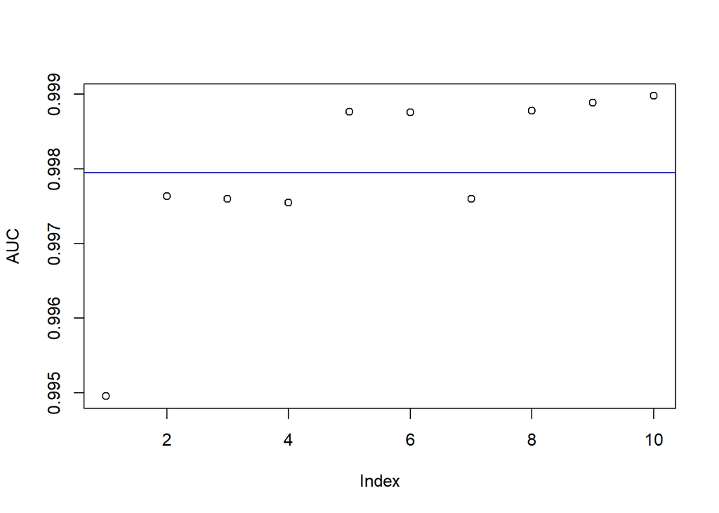

```r
plot(AUC)
abline(h= mean(AUC), col = "blue")
```

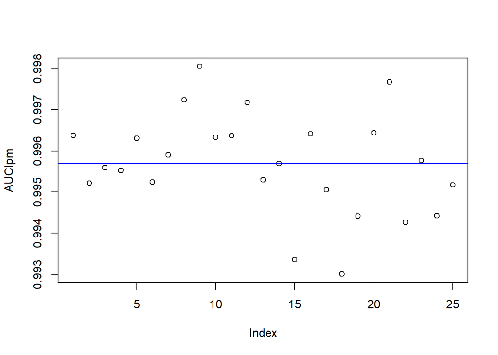

```r
plot(AUClpm)
abline(h= mean(AUClpm), col = "blue")
```